# 最新拼图包Patchwork教程之layout

首都医科大学-李志伟

2020/9/23

# patchwork简介

`patchwork`包是2019年12月新推出的一个用于将`ggplot`输出的图片组合的包，并且默认是对齐不同图片中的坐标轴的，其语法非常的简洁。接下来我们一起学一下用`patchwork`包设置图片的布局。

首先我们先加载2个包, `patchwork`包用来组合图片，`ggplo2`包用来绘图。

```r
library(patchwork)
library(ggplot2)
```

然后我们绘制4张简单的图，使用的数据是R自带的`mtcars`数据集。

```r
p1 <- ggplot(mtcars) +
  geom_point(aes(mpg, disp)) +
  ggtitle('Plot 1')

p2 <- ggplot(mtcars) +
  geom_boxplot(aes(gear, disp, group = gear)) +
  ggtitle('Plot 2')

p3 <- ggplot(mtcars) +
  geom_point(aes(hp, wt, colour = mpg)) +
  ggtitle('Plot 3')

p4 <- ggplot(mtcars) +
  geom_bar(aes(gear)) +
  facet_wrap(~cyl) +
  ggtitle('Plot 4')
```

# 在组合图中添加空白区域

有时候我们需要在两张图片中间添加一片空白区域，这时候我们就用到了`plot_spacer()`。他会像你组合的其他图片一样占据一个格子。

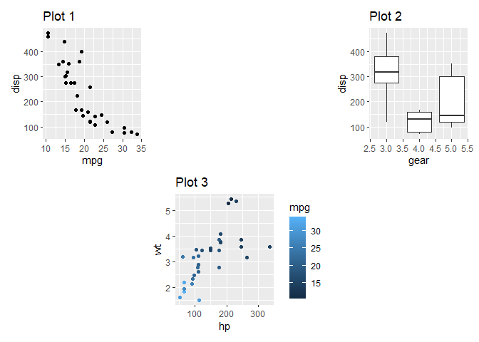

```r
p1 + plot_spacer() + p2 + plot_spacer() + p3 + plot_spacer()
```

值得注意的是添加的空白区域是和你添加的图片大小有关的，当在不同水平的嵌套组合图中，他们将有不同的尺寸。

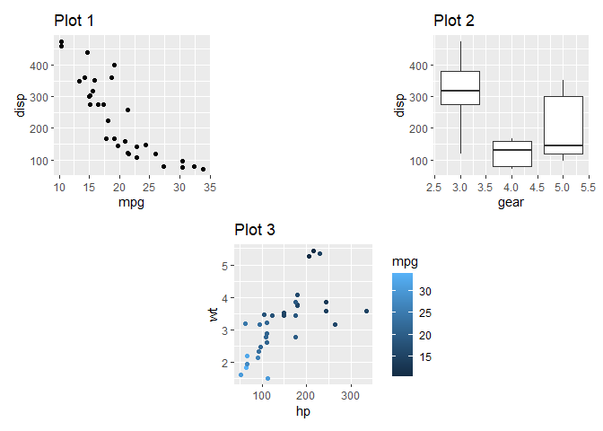

```r
(p1 + plot_spacer() + p2) / (plot_spacer() + p3 + plot_spacer())
```

# 掌控网格

如果你什么参数都不提供，那么`patchwork`会尽量让每个网格是一个正方形，每一行和每一列的网格都占据同样的空间，并且可以使用`plot_layout()`函数来控制他们。

`ncol = 3`是设置拼图为3列。

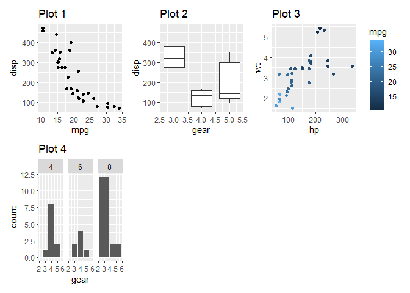

```r
p1 + p2 + p3 + p4 +
  plot_layout(ncol = 3)
```

`widths = c(2, 1)`是设置第一列和第二列宽度的比例。

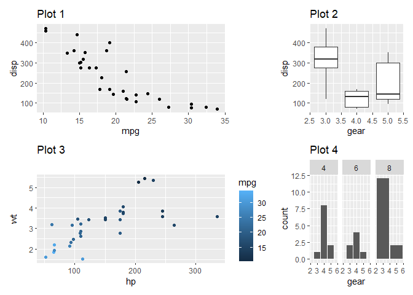

```r
p1 + p2 + p3 + p4 +
  plot_layout(widths = c(2, 1))
```

如果提供数值型向量给网格尺寸参数，将会定义绘图网格的相对大小，上边我们设置了第一列的宽度是第二列的两倍。同时，我们还可以设置带单位的数值型向量来控制网格的尺寸。

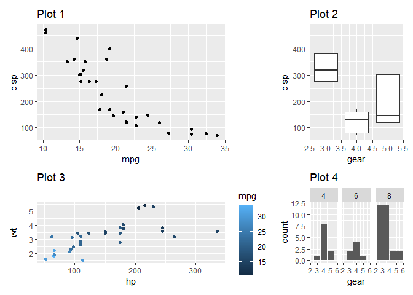

```r
p1 + p2 + p3 + p4 +
  plot_layout(widths = c(2, 1), heights = unit(c(5, 1), c('cm', 'null')))
```

上边代码输出的图片中，第一行的图片（Plot 1 和 Plot 2）将永远都是5cm，而第二行将会自动设置高度直到填满整张图。（因为5的单位是cm，而1的单位是null）

# 超越网格

之前如果我们想实现非网格化的拼图是使用的嵌套，但是这会使来自不同子区域中的图片不能对齐。

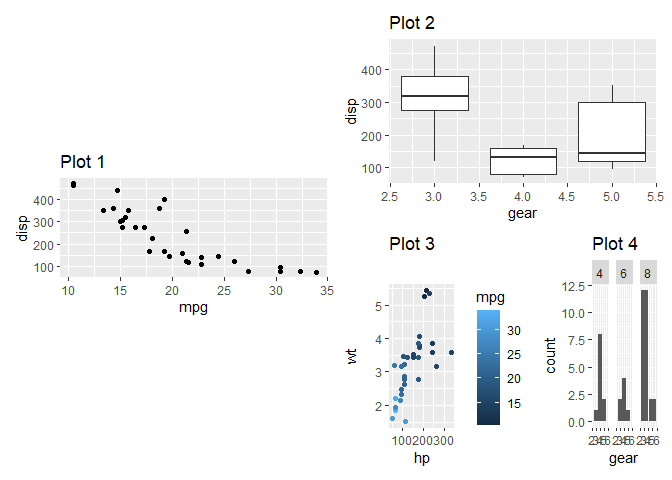

```r
# 设置左边图片的拼图格式
left <- plot_spacer() /
        p1 /
        plot_spacer()

# 设置右边的拼图格式
right <-    p2 /
        (p3 + p4)

# 最后将左边和右边并排组合
left | right
```

另外一种方法就是使用自定义的布局设计，有两种方法可以实现自定义布局设计，其中最简单就是用文字表示。

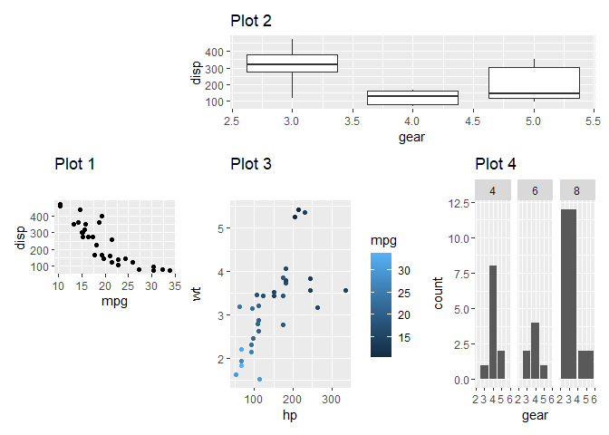

```r
layout <- "
##BBBB
AACCDD
##CCDD "
 p1 + p2 + p3 + p4 +
  plot_layout(design = layout)
```

可以看到，相比于第一次用嵌套方法输出的图片，使用自定义布局设计输出的拼图中，Plot 1和Plot 3的上方是水平对齐的。

在使用文本自定义布局时，你需要确保每个区域都是矩形的，但是有一个例外，那就是 `#`，井号表示空白区域，并且他可以变成任何形状。

另外一种编程化方法是使用`area()`函数来自定义布局。这种方法看起来有些啰嗦(不仅啰嗦，还他妈难以理解，我花了一晚上才将将理解是什么意思，每次输入个数，都得反应半天这个绘图区域是多大)，但是R更容易理解这种方法，并且它允许图片重叠。

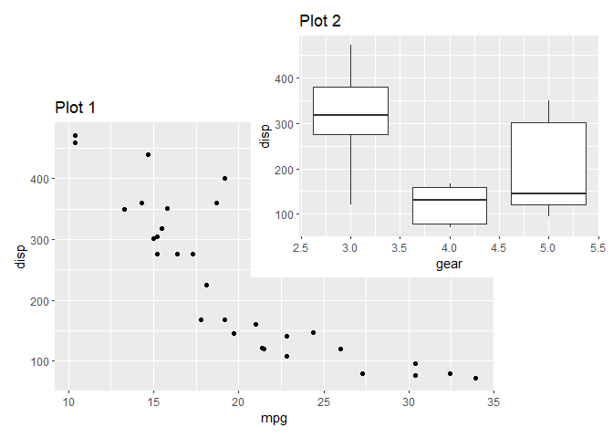

```r
layout <- c(
  area(t = 2, l = 1, b = 5, r = 4),
  area(t = 1, l = 3, b = 3, r = 5)
)
p1 + p2 +
  plot_layout(design = layout)
```

为了让大家更容易理解，我们使用`plot()`和`area()`来可视化绘图区域。

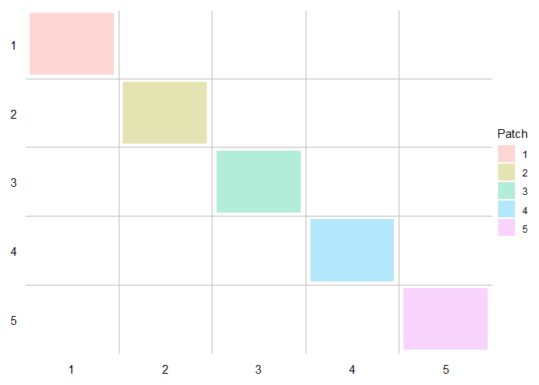

```r
layout <-  c(area(1, 1, 1, 1),
             area(2, 2, 2, 2),
             area(3, 3, 3, 3),
             area(4, 4, 4, 4),
             area(5, 5, 5, 5))

plot(layout)
```

图中5个带颜色的格子就是将来组合图片的时候会显示图片的地方，其他空白的格子在组合图片的时候也会是空白。

在`help(area)`中我们可以看到:

> that t and l should always be less or equal to b and r respectively.

意思是说上边的值(top)和左边的值(left)要小于等于下边的值（bottom）和右边的值（right）。因为如果超过的话，就上下颠倒，左右颠倒了，会报错的。接下来用人话解释一下。

上边的代码直接写1,2,3,4可能不好理解，我们换一种表达方式。

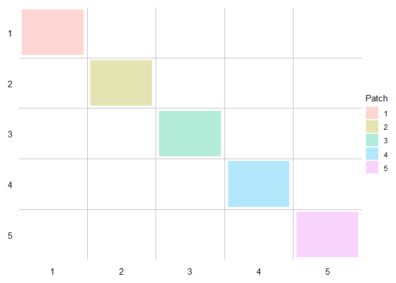

```r
layout <-  c(area(       t = 1,
                  l  = 1,        r = 1,
                         b = 1
                  ),
             area(2, 2, 2, 2),
             area(3, 3, 3, 3),
             area(4, 4, 4, 4),
             area(5, 5, 5, 5))
plot(layout)
```

同样的代码，加上了形式参数，然后调整一下摆放位置，上边在上边，下边在下边，左边在左边，右边在右边（废话！），接下来再调整参数就好理解了。**记住，左上的值(t和l)要分别小于右下的值(b和r)**。

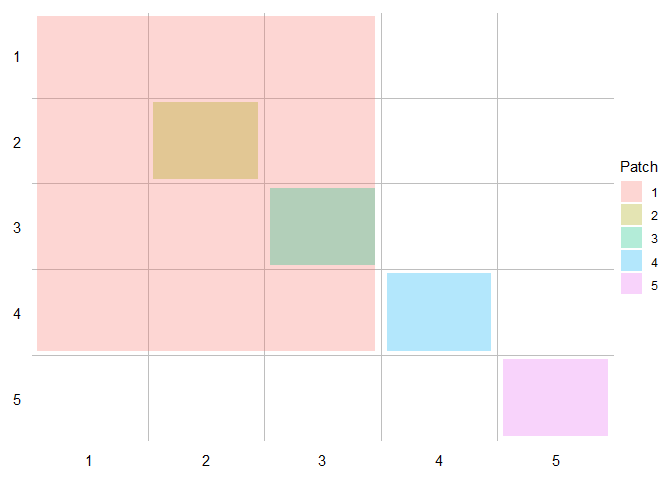

```r
layout <-  c(area(       t = 1,
                  l  = 1,        r = 3,
                         b = 4
                  ),
             area(2, 2, 2, 2),
             area(3, 3, 3, 3),
             area(4, 4, 4, 4),
             area(5, 5, 5, 5))
plot(layout)
```

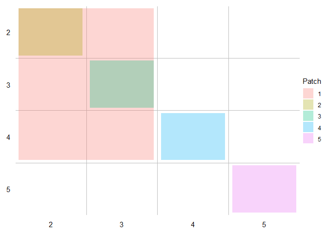

```r
layout <-  c(area(       t = 2,
                  l  = 2,        r = 3,
                         b = 4
                  ),
             area(2, 2, 2, 2),
             area(3, 3, 3, 3),
             area(4, 4, 4, 4),
             area(5, 5, 5, 5))
plot(layout)
```

为什么整个绘图区域变了呢，因为在`t = 1`和`l = 1`的区域都空白的，所以R默认将它删掉了，我们可以假装要在最左上角的1×1的网格中绘图，这时，整个绘图区域就会和之前一样了。

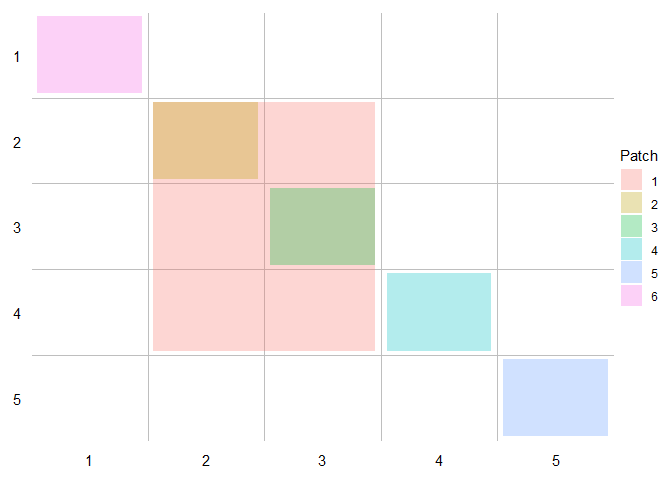

```r
layout <-  c(area(       t = 2,
                  l  = 2,        r = 3,
                         b = 4
                  ),
             area(2, 2, 2, 2),
             area(3, 3, 3, 3),
             area(4, 4, 4, 4),
             area(5, 5, 5, 5),
             area(1, 1, 1, 1)) #*****这里我加了一个1×1的绘图区域**********#
plot(layout)
```

接下来我们在绘图网格中填充图片。首先我们还是先看一下我们的3个绘图网格。

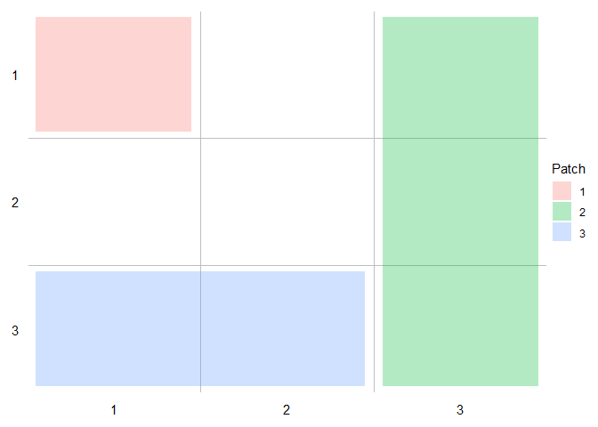

```r
layout <- c(
  area(1, 1),
  area(1, 3, 3),
  area(3, 1, 3, 2)
)

# Show the layout to make sure it looks as it should
plot(layout)
```

然后我们在绘图网格中填入相应的图片。

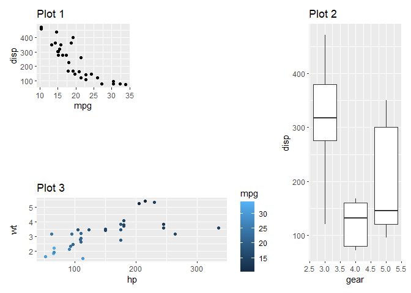

```r
# Apply it to a patchwork
p1 + p2 + p3 + plot_layout(design = layout)
```

可以看到图片的分布和颜色块的分布是相对应的。

`design`参数另外一个小功能是和`wrap_plots()`函数一起用，如果你给`design`参数一串文本，你就可以用文本中的字母代替你图片的名字。

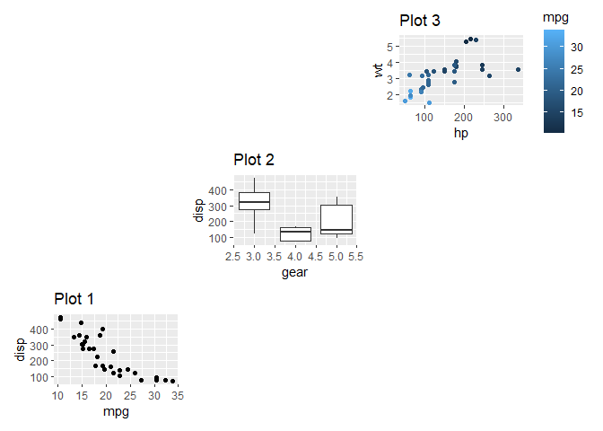

```r
layout <- '
A#B
#C#
D#E'
 wrap_plots(D = p1, C = p2, B = p3, design = layout)
```

拼图时的一种特殊情况是处理锁定纵横比方面图时，比如使用`coord_fixed()、coord_polar()和coord_sf()`创建的图。如果你既想让图片等比例缩放，又想让图片坐标轴对齐，那是不能能的。`plot_layout()`里边的参数`widths`和`heights`参数的默认值是`NA`。它的表现形式就像单位是`1 null`一样，会自动填充可用的空间。但是如果拼图网格的行或列中有固定纵横比的图片时，空白部分会扩展，图片部分会收缩。

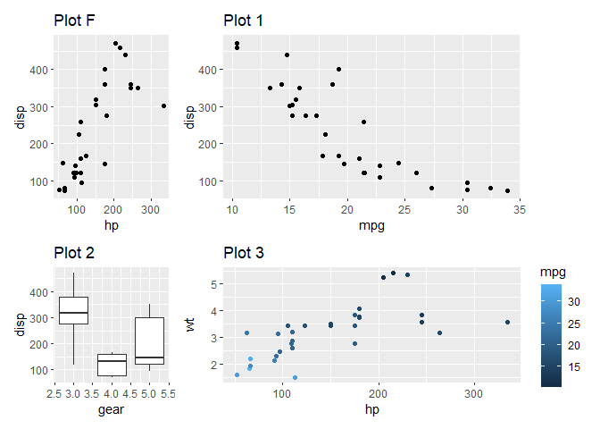

```r
p_fixed <- ggplot(mtcars) +
  geom_point(aes(hp, disp)) +
  ggtitle('Plot F') +
  coord_fixed()
p_fixed + p1 + p2 + p3
```

与此相比，设置宽度为非na值:

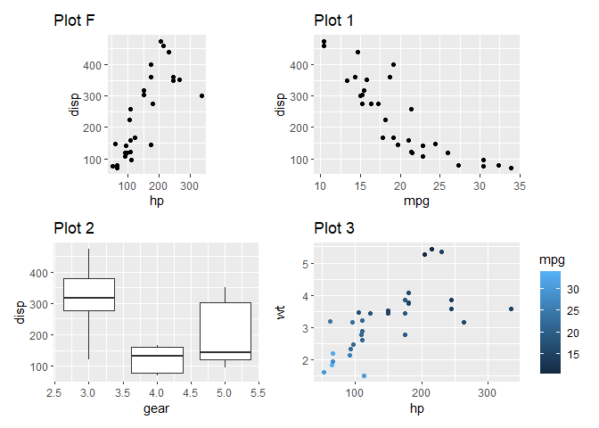

```r
p_fixed + p1 + p2 + p3 + plot_layout(widths = 1)
```

# 掌控图例

图例可以让我们更好的了解图片中的内容，当我们在拼图的时候要考虑我们如何处理图例。一般情况下我们不做任何处理，就是让每张图的图例都待在相应图片的旁边(如果有图例的话)。

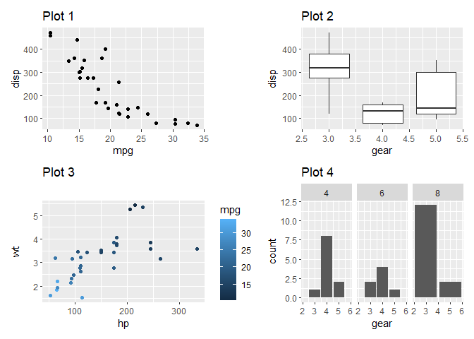

```r
p1 + p2 + p3 + p4
```

从下边的例子我们可以看到，图例的位置在`plot 3`的旁边，`plot_layout()`函数中有一个参数叫`guides`, 通过这个参数我们可以控制图例，我们看看如果将参数设置为`'collect'`会怎么样：

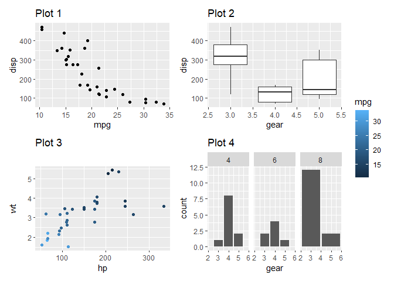

```r
p1 + p2 + p3 + p4 +
  plot_layout(guides = 'collect')
```

我们可以看到图例被放置在了所有拼图的一侧，与`'collect'`相对应的是`'keep'`, 他将让图例总是呆在相应图片的旁边。`guides`的默认值是`'auto'`, 它是介于两者之间的一种选择。它一般不会收集图例，但是如果拼图是由多个嵌套的拼图组成，而且其中某个拼图的`guides`被设置为`'collect'`, 那么设置为`'auto'`的拼图也会被收集。对比下边两个例子。

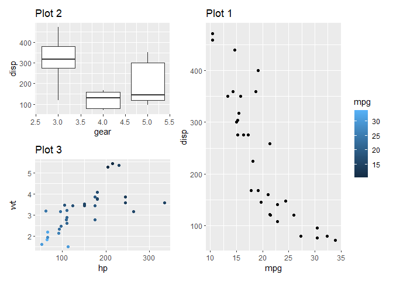

```r
((p2 / p3 + plot_layout(guides = 'auto')) | p1) + plot_layout(guides = 'collect')
```

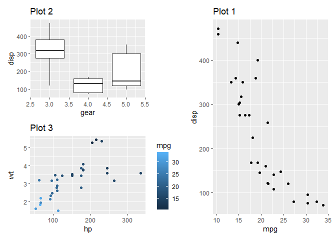

```r
((p2 / p3 + plot_layout(guides = 'keep')) | p1) + plot_layout(guides = 'collect')
```

`guides`参数还有一个神奇的功能，就是如果你拼图的时候有多个重复的图例，并且你不想重复展示，`gudies`可以比较这些图例并且删除重复的图例。

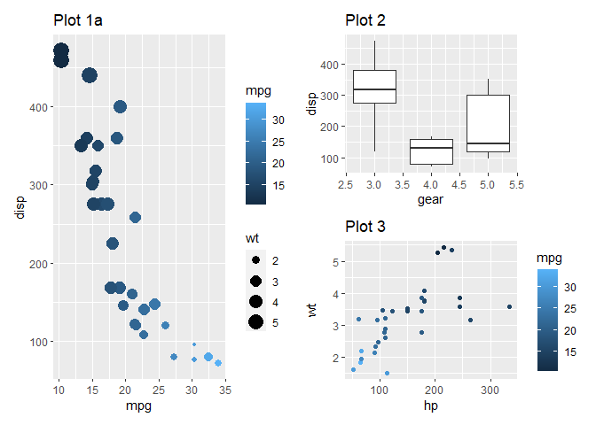

```r
p1a <- ggplot(mtcars) +
  geom_point(aes(mpg, disp, colour = mpg, size = wt)) +
  ggtitle('Plot 1a')

p1a | (p2 / p3)
```

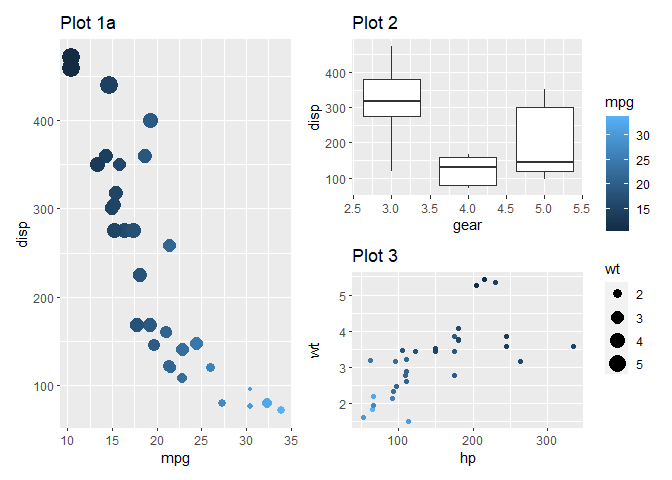

```r
(p1a | (p2 / p3)) + plot_layout(guides = 'collect')
```

`guides`参数看的是图形映射，不是图例中的文字信息，换句话说，如果两个图例的文字信息是一样的，但是是不同的图形映射，那么图例将不会被合并。

你在拼图时，有时候会空出一片区域。与其让他留白不如在上边放点东西，比如说图例，我们可以使用`guide_area()`函数实现这个功能，他有点像`plot_spacer()`，如果`guides`没有被设置为`'collect'`，那么`guide_area()`和`plot_spacer()`将没有区别。

```r
p1 + p2 + p3 + guide_area() +
  plot_layout(guides = 'keep') #****** keep  *********#
```

[output not shown]

```r
p1 + p2 + p3 + guide_area() +
  plot_layout(guides = 'auto') #****** auto  *********#
```

[output not shown]

```r
p1 + p2 + p3 + plot_spacer()  #****** spacer  *********#
```

[output not shown]

但是如果你将`guides`设置为`'collect'`, 空白区域将会显示图例。

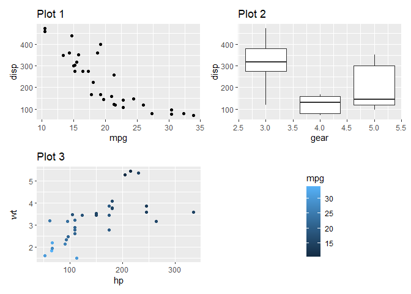

```r
p1 + p2 + p3 + guide_area() +
  plot_layout(guides = 'collect')
```

图例区域只能在相同的嵌套级别上显示。如果一个嵌套拼图有一个图例区域，那么它将不可能将收集到的图例放置在更高的级别。

# 了解更多

这就是关于布局方便的全部知识，关于patchwork还有更多功能。点击 [annotations](https://patchwork.data-imaginist.com/articles/guides/annotation.html), [special operators](https://patchwork.data-imaginist.com/articles/guides/assembly.html) 和 [multipage alignment](https://patchwork.data-imaginist.com/articles/guides/multipage.html)可以了解更多。